# BAMS 503 Final Project: Virgin Mobile Pricing Strategy Analysis

Mina Chen, Ruijia Wang, Yelin Fan, Li Fang

May 29, 2021

### Introduction

When any business is considering entering a market, a pile of go-to-market strategies will be evaluated and determined. The pricing decision is one of the most crucial ones. Customer lifetime value(CLV) is a primary metric for understanding customers. To be more precise, this metric is a prediction of the value that a paying customer could bring to a business. It provides a picture of the business’s long-term financial viability. Under different pricing decisions, predicted CLV could be used for defining pricing policy, targeting customer segments, and supporting decision making. However, the process of predicting CLV before the product launch involves a variety of uncertainties, including profit, customer retention, acquisition costs, and so on. Directly using the average of these parameters to calculate CLV may lead to a ‘flaw of average’ estimate and may mask meaningful differences within the customer population. The advantages of the Monte Carlo Simulation application in this context are significant. The purpose of the current case is to determine a practical simulation model for predicting CLV wherefore to evaluate different pricing options.

A case of Virgin Mobile, a U.K.-based wireless phone service provider who was considering entering the U.S. market in 2001, is used as a basis for discussion. Virgin Mobile had two pricing and service subscription contract structure: (1) using a standard subscription contract plan, (2) a radically new pay-per-use pricing plan that eliminates subscription contracts. Our approach is to simulate the CLV of an individual customer under each pricing option and draw insights based on the simulation results. Different assumptions will be made in the simulation model, including but not only customer time usage distribution, customer acquisition result, the probability of usage over-estimation, and so on. Our base model simulates constant churn rates for contract and non contract options. The case of dynamic churn rate is illustrated in “what-if” scenario one, where we assume the customer follows two different patterns of churning. Part three includes the analysis of another what-if scenario when acquisition costs are affected by different numbers of customer bases.

### Model Description

We used the below formula to calculate the net CLV of a customer, taking into consideration the present value of expected future cash flow.
$$\text{Net CLV} = \sum^{T}_{t=1} {\frac{m_t}{(1+t)^t}} - \text{AC}$$
Where:

- m_t = profit margin during month t
- i = constant monthly discount rate for discounted cash flow
- t = month (the present is at t=0)
- T = total lifetime of the customer (in months)
- AC = acquisition cost

To analyze the decision of providing a contract or no contract pricing scheme, we generated net CLV for 1000 customers under two scenarios and compared the average net CLV.

There is very little data given in the case and most of the inputs are based on reasonable assumptions. Key model inputs and assumptions are as follows:

- Annual discount rate is constant at 5%.
- The maximum period we consider for CLV calculation is 10 years (120 months).
- Monthly service cost for each customer is $30. This includes the cost of telecommunication infrastructures, customer service representative cost and various operation costs. In reality, this cost changes depending on the size of the customer base.
- Acquisition cost per customer follows a uniform distribution with minimum $200 and maximum $540. This cost is on the higher end since Virgin Mobile is new in the USA and needs more marketing to attract customers.
- Actual usage of calling time per customer follows a normal distribution with a mean of 300 minutes and standard deviation of 20 minutes.

Additional assumptions for contract option：

- Virgin Mobile provided only one type of contract mobile plan to customers when it first entered the U.S., which was a $50 monthly fee with a limit of 300 minutes of calling time.
- Contract period is 24 months. This contract length is used by most telecommunication companies.
- To cancel the contract prematurely, customers need to pay a cancellation penalty of a fixed $50 plus $10 for every remaining month in the contract period.
- After 24 months, if the customers still stay, the same plan will continue without penalty for cancellation afterwards.
- Contract customers’ churn rate is constant at 2% per month.
- If a customer’s actual usage exceeds the allowance in the plan (300 min), Virgin Mobile charges 12 cents for every extra minute.

Additional assumptions for no contract option:

- Without a contract, the customer churn rate is constant at 6% per month.
- Calling time usage is charged in three tiers. If usage <200 minutes, Virgin Mobile charges 25 cents per minute. For minutes used between 200 and 300 minutes, Virgin Mobile charges 20 cents per minute. For minutes used above 300 minutes, Virgin Mobile charges 15 cents per minute. Charging lower rates for higher tiers is an existing industry price structure mentioned in the case.

### Baseline Model

Constant churn rate for contract and non-contract scenarios.

#### Lifetime Value of a customer with a contract

Constant churn rate at 2% for each period.

```r
#Constant churn rate for contract and non-contract scenarios
#####################################################################
# Function: confidence_interval
# What it does: returns the desired confidence interval bounds around a sample average, obtained from a vector of input data
#####################################################################
confidence_interval <- function(vector, interval) {
  # Standard deviation of sample
  vec_sd <- sd(vector)
  # Sample size
  n <- length(vector)
  # Mean of sample
  vec_mean <- mean(vector)
  # Error according to t distribution
  error <- qt((interval + 1)/2, df = n - 1) * vec_sd / sqrt(n)
  # Confidence interval as a vector
  result <- c(vec_mean - error, vec_mean + error)
  return(result)
}
##Scenario 1
##Lifetime Value of a Customer With a Contract: Constant Churn Rate at 2% for each period
contract_period<-24#if a customer churns before the period ends, he will be charged break_contract_fee = 50+10*(contract period remained)
churn_rate_contract<-0.02#churn rate for contract customers
retention_rate<-1-churn_rate_contract #retention rate for contract customers
allowance_usage<-300 #monthly allowed usage within the contract
beyond_usage_cost_tier1<-0.12#if the contract customer exceeds the usage (300), the extra will be charged at 12 cents/min

monthly_service_cost<-30 #the monthly cost of Virgin mobile for each customer
monthly_service_charge<-50 #the amount Virgin mobile charges for contract customers
annunal_interest_rate<-0.05
monthly_interest_rate<-(1+annunal_interest_rate)^(1/12)-1

maxperiod<-120#months
clv<-c()
life_time<-c()
lifetime_value<-c()
customer_life<-c()
mean_usage<-c()

num_reps<-1000

set.seed(1)

for (i in 1:num_reps){
  lifetime_margin<-rep(0,maxperiod)
  usage<-rep(0,maxperiod)
  acquisition_cost<-runif(1,200,540)#uniform distribution to simulate acquisition cost for each customer
  customer_active=1 #customer confirm active at period 1
  num_period = 0
  while(customer_active==1 & num_period<maxperiod){
    t=num_period+1
    #returns 1 if the customer is active;otherwise 0
    life_time[t]<-customer_active #record the active status of customer at time t
    discount_rate<-(1+monthly_interest_rate)^t #discount of cash flow at time t
    total_usage<-rnorm(1,300,20) #generate the monthly usage of the active customer
    usage[t]<-total_usage #record the total usage at time t
    over_usage<-max(total_usage-allowance_usage,0) #check how many minutes the customer overused
    over_usage_charge<-over_usage*beyond_usage_cost_tier1
    monthly_margin<-monthly_service_charge+over_usage_charge-monthly_service_cost#total profit from this customer
    lifetime_margin[t]<-monthly_margin/discount_rate#clv formula, get the discounted lifetime value
    num_period=num_period+1
    customer_active<-rbinom(1,1,retention_rate)
  }
 # print(lifetime_margin)
  customer_life[i]<-num_period
  if(customer_life[i]< contract_period){
    break_contract_fee<-50+10*(contract_period-t+1)#charge break contract fee if the customer left before the contract ends
  lifetime_value[i]<-sum(lifetime_margin) -acquisition_cost +break_contract_fee
  }else{
  lifetime_value[i]<-sum(lifetime_margin)-acquisition_cost
  }
 # print(lifetime_value[i])
 # clv[i]<-sum(lifetime_margin)
  mean_usage[i]<-mean(usage)
}

df_c<-matrix(0,nrow=num_reps,ncol=3)
colnames(df_c)<-c("lifetime_value","customer_life","mean_usage")
df_c[,1]<-lifetime_value
df_c[,2]<-customer_life
df_c[,3]<-mean_usage
#View(df_c)
```

```r
avg_clv_c<-mean(df_c[,"lifetime_value"])
ci_clv_c <- confidence_interval(lifetime_value, .95)
plus_minus_clv_c <- round(ci_clv_c[2] - avg_clv_c, 2) #plus_minus is the 95% CI half-width
print(sprintf("The average lifetime value (and 95%% CI half-width) is:$ %.2f +/- %.2f", avg_clv_c, plus_minus_clv_c))
```

```
## [1] "The average lifetime value (and 95% CI half-width) is:$ 523.47 +/- 34.17"
```

```r
avg_lt_c<-mean(df_c[,"customer_life"])
ci_lt_c <- confidence_interval(customer_life, .95)
plus_minus_lt_c <- round(ci_lt_c[2] - avg_lt_c, 2) #plus_minus is the 95% CI half-width
print(sprintf("The average customer life time (and 95%% CI half-width) is: %.2f month +/- %.2f", avg_lt_c, plus_minus_lt_c))
```

```
## [1] "The average customer life time (and 95% CI half-width) is: 45.56 month +/- 2.28"
```

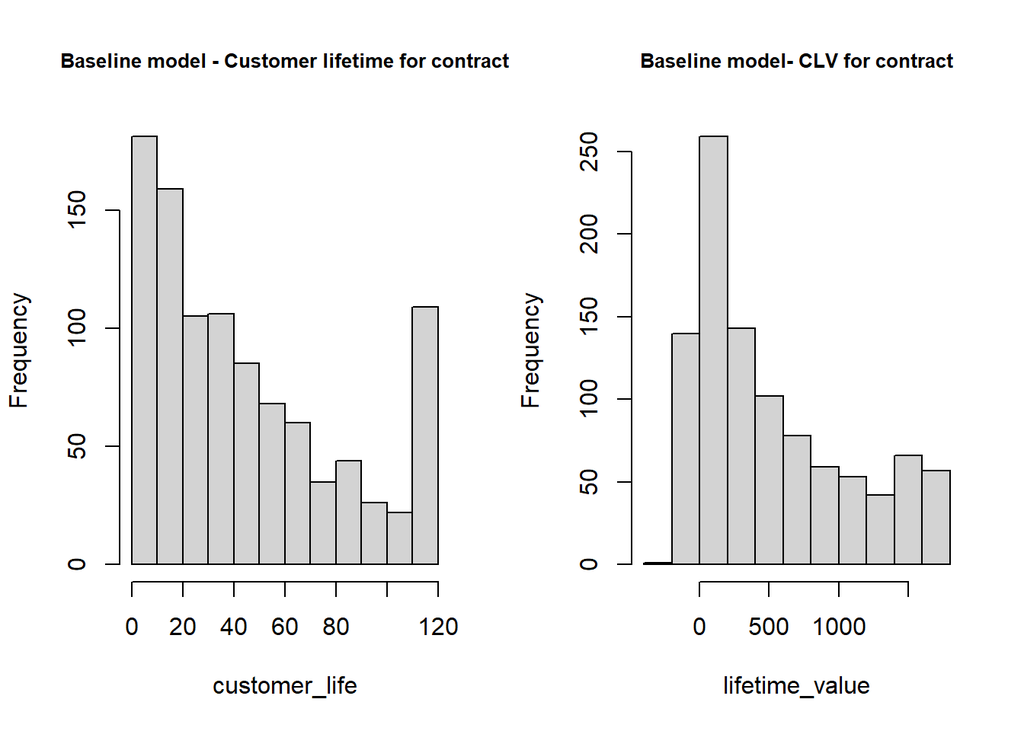

```r
#plot(lifetime_value~customer_life)
#plot(lifetime_value~mean_usage)
par(mfrow=c(1,2))
hist(customer_life,main='Baseline model - Customer lifetime for contract',cex.main=0.8)
hist(lifetime_value,main='Baseline model- CLV for contract',cex.main=0.8)
```

#### Lifetime Value of a customer without a contract

Constant churn rate at 6%. Non contract is flexible, charges the customers by their practical usage.

```r
churn_rate_noncontract<-0.06 #churn rate for non contract customers
retention_rate<-1-churn_rate_noncontract #churn rate for non contract customers
usage_tier1<-200 #different usage tiers for non contract customers
usage_tier2<-300
#usage_tier3 >300
usage_price_tier1<-0.25# if the usage is <200, 25 cents/min
usage_price_tier2<-0.20# if the usage is <300, 20 cents/min
usage_price_tier3<-0.15# if the usage is >300, 15 cents/min

monthly_service_cost<-30 #Virgin mobile's monthly cost
#monthly_service_charge= usage*tier_price by tiers

annunal_interest_rate<-0.05
monthly_interest_rate<-(1+annunal_interest_rate)^(1/12)-1

maxperiod<-120#months
clv<-c()
lifetime_margin<-c()
life_time<-c()
lifetime_value<-c()
customer_life<-c()
usage<-c()
mean_usage<-c()

num_reps<-1000

set.seed(123)

for (i in 1:num_reps){
  lifetime_margin<-rep(0,maxperiod)
  usage<-rep(0,maxperiod)
  acquisition_cost<-runif(1,200,540)#uniform distribution to simulate acquisition cost for each customer
  customer_active=1 #customer confirm active at period 1
  num_period = 0

  while(customer_active==1 & num_period<maxperiod){
    t=num_period+1
    #returns 1 if the customer is active;otherwise 0
    life_time[t]<-customer_active #record the active status of customer at time t
    discount_rate<-(1+monthly_interest_rate)^t #discount of cash flow at time t
    total_usage<-rnorm(1,300,20) #generate the monthly usage of the active customer
    usage[t]<-total_usage #record the total usage at time t
    if(total_usage > usage_tier2){#charge the customer based on the usage range
      usage_charge<-usage_tier1*usage_price_tier1 + (usage_tier2-usage_tier1)*usage_price_tier2 + (total_usage-usage_tier2)*usage_price_tier3
    }
    else if(total_usage > usage_tier1){
      usage_charge<-usage_tier1*usage_price_tier1+(total_usage-usage_tier1)*usage_price_tier2}
    else{
      usage_charge<-total_usage*usage_price_tier1}
    monthly_margin<-usage_charge-monthly_service_cost
    lifetime_margin[t]<-monthly_margin/discount_rate#clv formula, get the discounted lifetime value
    num_period=num_period+1
    customer_active<-rbinom(1,1,retention_rate)
  }
  customer_life[i]<-num_period
  clv[i]<-sum(lifetime_margin)-acquisition_cost
  mean_usage[i]<-mean(usage)
}

df_nc<-matrix(0,nrow=num_reps,ncol=3)
colnames(df_nc)<-c("lifetime_value","customer_life","mean_usage")
df_nc[,1]<-clv
df_nc[,2]<-customer_life
df_nc[,3]<-mean_usage
#View(df_nc)
```

```r
#mean(df_nc[,"lifetime_value"])
#mean(df_nc[,"customer_life"])

avg_clv_nc<-mean(df_nc[,"lifetime_value"])
ci_clv_nc <- confidence_interval(df_nc[,"lifetime_value"], .95)
plus_minus_clv_nc <- round(ci_clv_nc[2] - avg_clv_nc, 2) #plus_minus is the 95% CI half-width
print(sprintf("The average lifetime value (and 95%% CI half-width) is:$ %.2f +/- %.2f", avg_clv_nc, plus_minus_clv_nc))
```

```
## [1] "The average lifetime value (and 95% CI half-width) is:$ 266.19 +/- 37.19"
```

```r
avg_lt_nc<-mean(df_nc[,"customer_life"])
ci_lt_nc <- confidence_interval(customer_life, .95)
plus_minus_lt_nc <- round(ci_lt_nc[2] - avg_lt_nc, 2) #plus_minus is the 95% CI half-width
print(sprintf("The average customer life time (and 95%% CI half-width) is: %.2f month +/- %.2f", avg_lt_nc, plus_minus_lt_nc))
```

```
## [1] "The average customer life time (and 95% CI half-width) is: 17.32 month +/- 1.05"
```

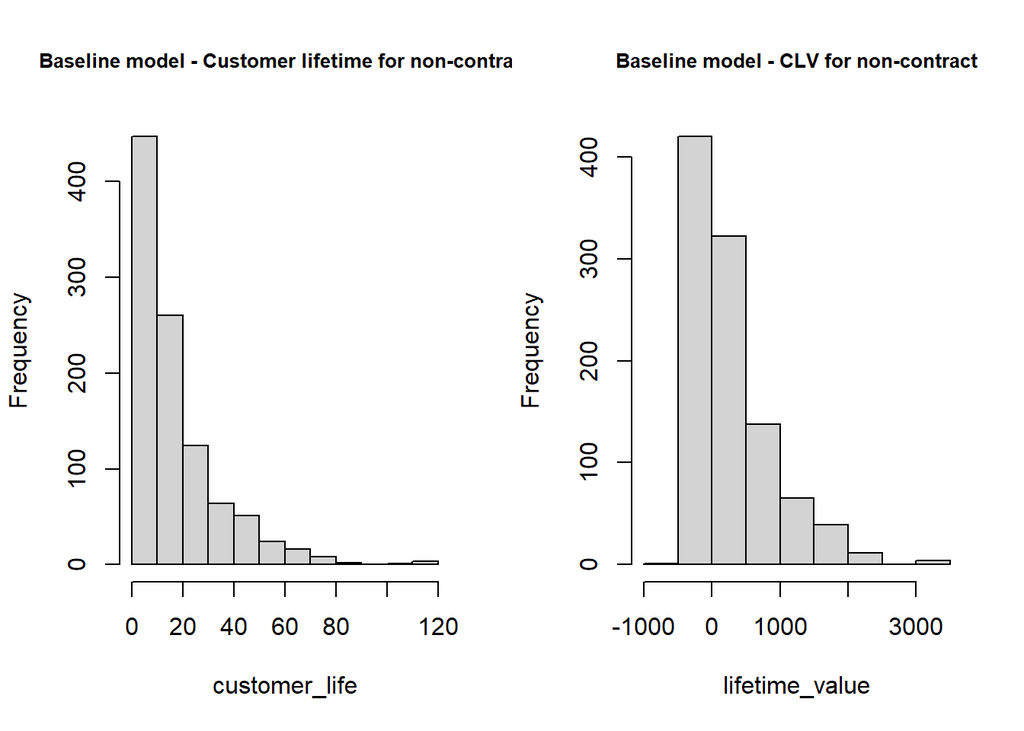

```r
#plot(clv~customer_life)
#plot(clv~mean_usage)
par(mfrow=c(1,2))
hist(customer_life,main="Baseline model - Customer lifetime for non-contract",cex.main=0.8)
hist(df_nc[,"lifetime_value"],main='Baseline model - CLV for non-contract',cex.main=0.8,xlab="lifetime_value")
```

### Result of Baseline Model

Based on simulation results, the average CLV for contract customers is $523.47 (plus/minus 34.17 for 95% confidence interval), with an average lifetime of 46 months (plus/minus 2.28 for 95% confidence interval). The average CLV for non-contract customers is $266.19 (plus/minus 37.19 for 95% confidence interval), with an average lifetime of 17 months (plus/minus 1.05 for 95% confidence interval). Since there is no overlap of the two CLV confidence intervals, we are pretty sure that the contract option generates a higher CLV.

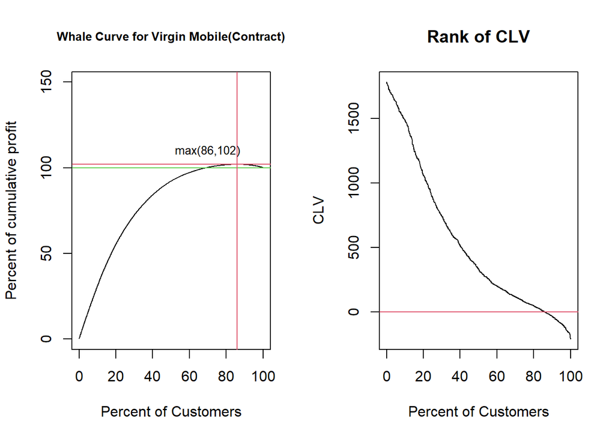

```r
#####################
# Whale Plot
#####################

whale.data<-as.data.frame(df_c[order(-df_c[,'lifetime_value'])] )#sort customers decreasing order of CLV
colnames(whale.data)<-"clv.ordered"
whale.data$clvpercent <- 100*(whale.data$clv.ordered/sum(whale.data$clv.ordered))
whale.data$clvcumpercent<-cumsum(whale.data$clvpercent)

whale.data$ncustomer<-seq(1,num_reps)
whale.data$percentcustomers<-100*whale.data$ncustomer/num_reps

par(mfrow=c(1,2))
plot(whale.data$percentcustomers,whale.data$clvcumpercent, type="l",
     ylim=c(0,150),main="Whale Curve for Virgin Mobile(Contract)"
     ,xlab = "Percent of Customers", ylab = "Percent of cumulative profit",cex.main=0.8)
abline(100,0,col=3)
abline(v=whale.data$percentcustomers[which.max(whale.data$clv.ordered<=0)],col=2)
abline(h=whale.data$clvcumpercent[which.max(whale.data$clv.ordered<=0)],col=2)
text(70,110,"max(86,102)", cex=0.8)

plot(whale.data$percentcustomers,whale.data$clv.ordered, type="l",
     main="Rank of CLV",
     xlab = "Percent of Customers", ylab = "CLV")
abline(h=0,col=2)
```

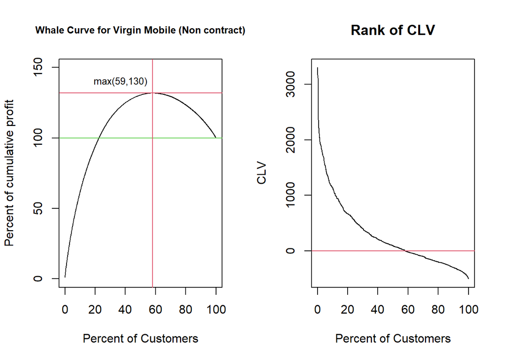

```r
#for non contract
whale.data2<-as.data.frame(df_nc[order(-df_nc[,'lifetime_value'])] )#sort customers decreasing order of CLV
colnames(whale.data2)<-"clv.ordered"
whale.data2$clvpercent <- 100*(whale.data2$clv.ordered/sum(whale.data2$clv.ordered))
whale.data2$clvcumpercent<-cumsum(whale.data2$clvpercent)

whale.data2$ncustomer<-seq(1,num_reps)
whale.data2$percentcustomers<-100*whale.data2$ncustomer/num_reps

par(mfrow=c(1,2))
plot(whale.data2$percentcustomers,whale.data2$clvcumpercent, type="l",
     ylim=c(0,150),main="Whale Curve for Virgin Mobile (Non contract)"
     ,xlab = "Percent of Customers", ylab = "Percent of cumulative profit",cex.main=0.8)
abline(100,0,col=3)
abline(v=whale.data2$percentcustomers[which.max(whale.data2$clv.ordered<=0)],col=2)
abline(h=whale.data2$clvcumpercent[which.max(whale.data2$clv.ordered<=0)],col=2)
text(37,140,"max(59,130)", cex=0.8)

plot(whale.data2$percentcustomers,whale.data2$clv.ordered, type="l",
     main="Rank of CLV",
     xlab = "Percent of Customers", ylab = "CLV")
abline(h=0,col=2)
```

Based on the current assumptions, Virgin Mobile should offer a contract price scheme to the potential customers. One thing to note is that the average CLV is only part of the picture. A high CLV does not necessarily mean higher total profit, which is equal to CLV times customer size. What-if Scenario two contains more detailed discussion pertaining to this.

Compared with aggregate level analysis, the individual analysis by Monte Carlo Simulation offers more insights on the differences in CLV among the customers. Such differences can be huge as illustrated by whale plots. On the whale plots, customers are ranked according to their profitability on the horizontal axis. The vertical axis indicates cumulative profits that these customers generate.

To conclude, the individual level analysis by Monte Carlo provides Virgin Mobile different aspects to compare these two pricing schema. For example, if Virgin Mobile has effective segmentation and targeting strategies for profit maximization, they might want to proceed with the non-contract schema. Similarly, if they want to achieve a faster turnover rate and gain profit with fewer customers, they should go with the non-contract option. However, if Virgin Mobile is not certain with the customer segmentation because they are new to the US market, they might want to choose the safer contract schema with fewer customers having negative CLV. While from aggregate level analysis, we could not obtain these insights and are only able to suggest that Virgin Mobile use contract schema as it could generate a higher average CLV.

### Analysis of “What-if” Scenarios

#### What-if One

If churn rate follows other patterns, how does it affect the CLV for the two options?

#### Case One

The customer is more likely to switch to another carrier during months 2-6 (with probability 6% per month), but if he or she has stayed with Virgin Mobile for 6 months, the probability of switching to another carrier decreases to 2% for subsequent months.

- churn rate=0.06 when t<=6
- churn rate=0.02 when t>6

##### Lifetime Value of a customer with a contract

```r
contract_period<-24#if a customer churns before the period ends, he will be charged break_contract_fee = 50+10*(contract period remained)

churn_rate1<-0.06 #churn rate=0.06 when t<=6
churn_rate2<-0.02 #churn rate=0.02 when t>6
period1<-6
#period2>6
retention_rate1<-1-churn_rate1
retention_rate2<-1-churn_rate2

allowance_usage<-300#monthly allowed usage within the contract
beyond_usage_cost_tier1<-0.12#if the contract customer exceeds the usage (300), the extra will be charged at 12 cents/min

monthly_service_cost<-30#the monthly cost of Virgin mobile for each customer
monthly_service_charge<-50#the amount Virgin mobile charges for contract customers
annunal_interest_rate<-0.05
monthly_interest_rate<-(1+annunal_interest_rate)^(1/12)-1

maxperiod<-120#months
clv<-c()
lifetime_margin<-c()
life_time<-c()
lifetime_value<-c()
customer_life<-c()
usage<-c()
mean_usage<-c()
break_contract_fee_v<-rep(0,num_reps)

num_reps<-1000

set.seed(123)

for (i in 1:num_reps){
  lifetime_margin<-rep(0,maxperiod)
  usage<-rep(0,maxperiod)
  acquisition_cost<-runif(1,200,540)#uniform distribution to simulate acquisition cost for each customer
  customer_active=1 #customer confirm active at period 1
  num_period = 0
  while(customer_active==1 & num_period<maxperiod){
    t=num_period+1
    #returns 1 if the customer is active;otherwise 0
    life_time[t]<-customer_active #record the active status of customer at time t
    discount_rate<-(1+monthly_interest_rate)^t #discount of cash flow at time t
    total_usage<-rnorm(1,300,20) #generate the monthly usage of the active customer
    usage[t]<-total_usage #record the total usage at time t
    over_usage<-max(total_usage-allowance_usage,0) #check how many minutes the customer overused
    over_usage_charge<-over_usage*beyond_usage_cost_tier1
    monthly_margin<-monthly_service_charge+over_usage_charge-monthly_service_cost#total profit from this customer
    lifetime_margin[t]<-monthly_margin/discount_rate#clv formula, get the discounted lifetime value
    num_period=num_period+1
    if(t<= period1){#the retention rate differs by the period
      customer_active<-rbinom(1,1,retention_rate1)}#returns 1 if the customer is active;otherwise 0
    else{
      customer_active<-rbinom(1,1,retention_rate2)
    }
  }
  customer_life[i]<-num_period
  if(customer_life[i]< contract_period){
    break_contract_fee<-50+10*(contract_period-t+1)#charge break contract fee if the customer left before the contract ends
    break_contract_fee_v[i]<-break_contract_fee
    lifetime_value[i]<-sum(lifetime_margin)-acquisition_cost+break_contract_fee
  }else{
    lifetime_value[i]<-sum(lifetime_margin)-acquisition_cost
  }
 # clv[i]<-sum(lifetime_margin)
  mean_usage[i]<-mean(usage)
}

df_c<-matrix(0,nrow=num_reps,ncol=3)
colnames(df_c)<-c("lifetime_value","customer_life","mean_usage")
df_c[,1]<-lifetime_value
df_c[,2]<-customer_life
df_c[,3]<-mean_usage
#View(df_c)
```

Mean of the simulated lifetime value and customer lifetime:

```r
mean(df_c[,"lifetime_value"])
```

```
## [1] 400.1261
```

```r
mean(df_c[,"customer_life"])
```

```
## [1] 36.22
```

```r
#plot(lifetime_value~customer_life)
#plot(lifetime_value~mean_usage)
par(mfrow=c(1,2))
#hist(customer_life, main = "Case one - Lifetime for contract")
#hist(lifetime_value, main = "Case one - CLV for contract")
```

##### Lifetime Value of a customer without a contract

```r
churn_rate1<-0.06 #churn rate=0.06 when t<=6
churn_rate2<-0.02 #churn rate=0.02 when t>6
period1<-6
#period2>6
retention_rate1<-1-churn_rate1
retention_rate2<-1-churn_rate2
usage_tier1<-200
usage_tier2<-300
#usage_tier3 >300
usage_price_tier1<-0.25# if the usage is <200, 25 cents/min
usage_price_tier2<-0.20# if the usage is <300, 20 cents/min
usage_price_tier3<-0.15# if the usage is >300, 15 cents/min

monthly_service_cost<-30

#monthly_service_charge= usage*tier_price (different for each tier)
annunal_interest_rate<-0.05
monthly_interest_rate<-(1+annunal_interest_rate)^(1/12)-1

maxperiod<-120#months
clv<-c()
lifetime_margin<-c()
life_time<-c()
lifetime_value<-c()
customer_life<-c()
usage<-c()
mean_usage<-c()

num_reps<-1000

set.seed(123)
for (i in 1:num_reps){
  lifetime_margin<-rep(0,maxperiod)
  usage<-rep(0,maxperiod)
  acquisition_cost<-runif(1,200,540)#uniform distribution to simulate acquisition cost for each customer
  customer_active=1 #customer confirm active at period 1
  num_period = 0

  while(customer_active==1 & num_period<maxperiod){
    t=num_period+1
    #returns 1 if the customer is active;otherwise 0
    life_time[t]<-customer_active #record the active status of customer at time t
    discount_rate<-(1+monthly_interest_rate)^t #discount of cash flow at time t
    total_usage<-rnorm(1,300,20) #generate the monthly usage of the active customer
    usage[t]<-total_usage #record the total usage at time t
    if(total_usage > usage_tier2){#charge the customer based on the usage range
      usage_charge<-usage_tier1*usage_price_tier1 + (usage_tier2-usage_tier1)*usage_price_tier2 + (total_usage-usage_tier2)*usage_price_tier3
    }
    else if(total_usage > usage_tier1){
      usage_charge<-usage_tier1*usage_price_tier1+(total_usage-usage_tier1)*usage_price_tier2}
    else{
      usage_charge<-total_usage*usage_price_tier1}
    monthly_margin<-usage_charge-monthly_service_cost
    lifetime_margin[t]<-monthly_margin/discount_rate#clv formula, get the discounted lifetime value
    num_period=num_period+1
    if(t<= period1){#the retention rate differs by the period
      customer_active<-rbinom(1,1,retention_rate1)}#returns 1 if the customer is active;otherwise 0
    else{
      customer_active<-rbinom(1,1,retention_rate2)
    }
  }
  customer_life[i]<-num_period
  clv[i]<-sum(lifetime_margin)-acquisition_cost
  mean_usage[i]<-mean(usage)
}

df<-matrix(0,nrow=num_reps,ncol=3)#make a dataframe to combine the key output
colnames(df)<-c("lifetime_value","customer_life","mean_usage")
df[,1]<-clv
df[,2]<-customer_life
df[,3]<-mean_usage
#View(df)
```

Mean of the simulated lifetime value and customer lifetime:

```r
mean(df[,"lifetime_value"])
```

```
## [1] 872.6213
```

```r
mean(df[,"customer_life"])
```

```
## [1] 36.22
```

```r
#plot(clv~customer_life)
#plot(clv~mean_usage)
par(mfrow=c(1,2))
#hist(clv, main="Case one - CLV for non-contract")
#hist(customer_life, main = "Case one - lifetime for non-contract")
```

#### Case Two

The customer is unlikely to switch to another carrier in months 2-3 (the probability of switching is only 1%), but the probability increases to 6% for the following 12 months, and to 30% after that.

- churn rate=0.01 when t<=3
- churn rate=0.06 when t<=15
- churn rate=0.30 when t>15

##### Lifetime Value of a customer with a contract

```r
contract_period<-24#if a customer churns before the period ends, he will be charged break_contract_fee = 50+10*(contract period remained)

churn_rate1<-0.01 #churn rate=0.01 when t<=3
churn_rate2<-0.06 #churn rate=0.06 when t<=15
churn_rate3<-0.30 #churn rate=0.30 when t>15
period1<-3
period2<-15
#period3 >15
retention_rate1<-1-churn_rate1
retention_rate2<-1-churn_rate2
retention_rate3<-1-churn_rate3

allowance_usage<-300#monthly allowed usage within the contract

beyond_usage_cost_tier1<-0.12#if the contract customer exceeds the usage (300), the extra will be charged at 12 cents/min

monthly_service_cost<-30
monthly_service_charge<-50 #
annunal_interest_rate<-0.05
monthly_interest_rate<-(1+annunal_interest_rate)^(1/12)-1

maxperiod<-120#months
clv<-c()
lifetime_margin<-c()
life_time<-c()
lifetime_value<-c()
customer_life<-c()
usage<-c()
mean_usage<-c()
break_contract_fee_v<-rep(0,num_reps)
num_reps<-1000

set.seed(123)
for (i in 1:num_reps){
  lifetime_margin<-rep(0,maxperiod)
  usage<-rep(0,maxperiod)
  acquisition_cost<-runif(1,200,540)#uniform distribution to simulate acquisition cost for each customer
  customer_active=1 #customer confirm active at period 1
  num_period = 0
  while(customer_active==1 & num_period<maxperiod){
    t=num_period+1
    #returns 1 if the customer is active;otherwise 0
    life_time[t]<-customer_active #record the active status of customer at time t
    discount_rate<-(1+monthly_interest_rate)^t #discount of cash flow at time t
    total_usage<-rnorm(1,300,20) #generate the monthly usage of the active customer
    usage[t]<-total_usage #record the total usage at time t
    over_usage<-max(total_usage-allowance_usage,0) #check how many minutes the customer overused
    over_usage_charge<-over_usage*beyond_usage_cost_tier1
    monthly_margin<-monthly_service_charge+over_usage_charge-monthly_service_cost#total profit from this customer
    lifetime_margin[t]<-monthly_margin/discount_rate#clv formula, get the discounted lifetime value
    num_period=num_period+1
    if(t<=period1){#the retention rate differs by the period
      customer_active<-rbinom(1,1,retention_rate1)}#returns 1 if the customer is active;otherwise 0
    else if(t<=period2){
      customer_active<-rbinom(1,1,retention_rate2)}
    else{
      customer_active<-rbinom(1,1,retention_rate3)
    }
  }
  customer_life[i]<-num_period
  if(customer_life[i]< contract_period){
    break_contract_fee<-50+10*(contract_period-t+1)#charge break contract fee if the customer left before the contract ends
    lifetime_value[i]<-sum(lifetime_margin)-acquisition_cost+break_contract_fee
    break_contract_fee_v[i]<-break_contract_fee
  }else{
    lifetime_value[i]<-sum(lifetime_margin)-acquisition_cost
  }
  # clv[i]<-sum(lifetime_margin)
  mean_usage[i]<-mean(usage)
}


df_c<-matrix(0,nrow=num_reps,ncol=3)
colnames(df_c)<-c("lifetime_value","customer_life","mean_usage")
df_c[,1]<-lifetime_value
df_c[,2]<-customer_life
df_c[,3]<-mean_usage
#View(df_c)
```

Mean of the simulated lifetime value and customer lifetime:

```r
mean(df_c[,"lifetime_value"])
```

```
## [1] 62.98529
```

```r
mean(df_c[,"customer_life"])
```

```
## [1] 12.875
```

```r
#plot(lifetime_value~customer_life)
#plot(lifetime_value~mean_usage)
par(mfrow=c(1,2))
#hist(customer_life,main="Case two - Lifetime for contract")
#hist(lifetime_value, main = "Case two - CLV for contract")
```

##### Lifetime Value of a customer without a contract

```r
churn_rate1<-0.01 #churn rate=0.01 when t<=3
churn_rate2<-0.06 #churn rate=0.06 when t<=15
churn_rate3<-0.30 #churn rate=0.30 when t>15
period1<-3
period2<-15
#period3 >15
retention_rate1<-1-churn_rate1
retention_rate2<-1-churn_rate2
retention_rate3<-1-churn_rate3

usage_tier1<-200
usage_tier2<-300
#usage_tier3 >300
usage_price_tier1<-0.25# if the usage is <200, 25 cents/min
usage_price_tier2<-0.20# if the usage is <300, 20 cents/min
usage_price_tier3<-0.15# if the usage is >300, 15 cents/min


monthly_service_cost<-30#Virgin mobile's monthly cost

#monthly_service_charge= usage*tier_price (different for each tier)
annunal_interest_rate<-0.05
monthly_interest_rate<-(1+annunal_interest_rate)^(1/12)-1

maxperiod<-120#months
clv<-c()
lifetime_margin<-c()
life_time<-c()
lifetime_value<-c()
customer_life<-c()
usage<-c()
mean_usage<-c()

num_reps<-1000

set.seed(123)
for (i in 1:num_reps){
  lifetime_margin<-rep(0,maxperiod)
  usage<-rep(0,maxperiod)
  acquisition_cost<-runif(1,200,540)#uniform distribution to simulate acquisition cost for each customer
  customer_active=1 #customer confirm active at period 1
  num_period = 0

  while(customer_active==1 & num_period<maxperiod){
    t=num_period+1
    #returns 1 if the customer is active;otherwise 0
    life_time[t]<-customer_active #record the active status of customer at time t
    discount_rate<-(1+monthly_interest_rate)^t #discount of cash flow at time t
    total_usage<-rnorm(1,300,20) #generate the monthly usage of the active customer
    usage[t]<-total_usage #record the total usage at time t
    if(total_usage > usage_tier2){#charge the customer based on the usage range
      usage_charge<-usage_tier1*usage_price_tier1 + (usage_tier2-usage_tier1)*usage_price_tier2 + (total_usage-usage_tier2)*usage_price_tier3
    }
    else if(total_usage > usage_tier1){
      usage_charge<-usage_tier1*usage_price_tier1+(total_usage-usage_tier1)*usage_price_tier2}
    else{
      usage_charge<-total_usage*usage_price_tier1}
    monthly_margin<-usage_charge-monthly_service_cost
    lifetime_margin[t]<-monthly_margin/discount_rate#clv formula, get the discounted lifetime value
    num_period=num_period+1
    if(t<=period1){#the retention rate differs by the period
      customer_active<-rbinom(1,1,retention_rate1)}#returns 1 if the customer is active;otherwise 0
    else if(t<=period2){
      customer_active<-rbinom(1,1,retention_rate2)}
    else{
      customer_active<-rbinom(1,1,retention_rate3)
    }
  }
  customer_life[i]<-num_period
  clv[i]<-sum(lifetime_margin)-acquisition_cost
  mean_usage[i]<-mean(usage)
}


df<-matrix(0,nrow=num_reps,ncol=3)
colnames(df)<-c("lifetime_value","customer_life","mean_usage")
df[,1]<-clv
df[,2]<-customer_life
df[,3]<-mean_usage
#View(df)
```

Mean of the simulated lifetime value and customer lifetime:

```r
mean(df[,"lifetime_value"])
```

```
## [1] 124.5376
```

```r
mean(df[,"customer_life"])
```

```
## [1] 12.875
```

```r
#plot(clv~customer_life)
#plot(clv~mean_usage)
par(mfrow=c(1,2))
#hist(customer_life, main="Case two - lifetime for non-contract")
#hist(clv,main="Case two - CLV for non-contract")
```

It is unrealistic for the customer retention rate to remain constant in the real business world. This indicator is dynamically changing with different user behavior. Some people may argue that younger generations are more likely to switch mobile plans due to poorer credit quality. Alternatively, loyal customers may also switch their carriers if they find more attractive plans. Therefore, we made two customer behavior pre assumptions on the retention rate, and built a model to analyze the average CLV under different changes.

Retention Case 1: The customer is more likely to switch to another carrier during months 2~6 (with probability 6% per month), but if he or she has stayed with Virgin Mobile for 6 months, the probability of switching to another carrier decreases to 2% for subsequent months. The Monte Carlo Simulation with 1000 replications provided us with the average CLV of an individual customer with/without contract. The average CLV of a term user (with contract) is lower than the average CLV of an evergreen user (without contract): $400.13 < $872.62.

Retention Case 2: The customer is unlikely to switch to another carrier in months 2-3 (the probability of switching is only 1%), but the probability increases to 6% for the following 12 months, and 30% after that. The Monte Carlo Simulation with 1000 replications provided us with the average CLV of an individual customer with/without contract. The average CLV of a user with contract is lower than the average CLV of a user without contract: $62.99 < $124.54.

From the above simulation results, we observed: (1) The change in user retention rate has a significant impact on the company’s profitability. When the retention rate is relatively stable, the profitability can be 2.7 times higher than the CLV with high churn rate. (2) Making recommendations based on the calculation of average CLV is sensitive to the variation of churn rates. Compared to the base model, our conclusion is flipped as the average CLV of the contract plan changes from $257.28 higher to $472.49 lower than the non-contract plan in case 1, and $61.55 lower in case two. This is because when we assume both contract and non contract customers follow the same churn rate pattern, the contract plan loses its advantage of longer customer lifetime and non contract generates higher monthly margin.

#### What-if Two

Consider acquisition cost and number of customer acquired are different for with and without contract. Constant churn rate for contract and non-contract scenarios.

```r
total_marketing_cost = 60000000
# Assume normal distribution of acquired customer
mean_contract_cust = 1000000
sd_contract_cust = 50000
set.seed(123)

total_contract_cust = rnorm(1, mean_contract_cust, sd_contract_cust)
contract_acquisition_cost<-total_marketing_cost/total_contract_cust

mean_no_contract_cust = 1500000
sd_no_contract_cust = 75000
set.seed(123)
total_no_contract_cust = rnorm(1,mean_no_contract_cust,sd_no_contract_cust)
no_contract_acquisition_cost<-total_marketing_cost/total_no_contract_cust
#Constant churn rate for contract and non-contract scenarios
```

##### Lifetime Value of a customer with a contract

Constant churn rate at 2% for each period.

```r
contract_period<-24#if a customer churns before the period ends, he will be charged break_contract_fee = 50+10*(contract period remained)
churn_rate_contract<-0.02#churn rate for contract customers
retention_rate<-1-churn_rate_contract #retention rate for contract customers
allowance_usage<-300 #monthly allowed usage within the contract
beyond_usage_cost_tier1<-0.12#if the contract customer exceeds the usage (300), the extra will be charged at 12 cents/min

monthly_service_cost<-30 #the monthly cost of Virgin mobile for each customer
monthly_service_charge<-50 #the amount Virgin mobile charges for contract customers
annunal_interest_rate<-0.05
monthly_interest_rate<-(1+annunal_interest_rate)^(1/12)-1

maxperiod<-120#months
clv<-c()
life_time<-c()
lifetime_value<-c()
customer_life<-c()
mean_usage<-c()

num_reps<-1000

set.seed(1)

for (i in 1:num_reps){
  lifetime_margin<-rep(0,maxperiod)
  usage<-rep(0,maxperiod)
  acquisition_cost<-contract_acquisition_cost
  customer_active=1 #customer confirm active at period 1
  num_period = 0
  while(customer_active==1 & num_period<maxperiod){
    t=num_period+1
    #returns 1 if the customer is active;otherwise 0
    life_time[t]<-customer_active #record the active status of customer at time t
    discount_rate<-(1+monthly_interest_rate)^t #discount of cash flow at time t
    total_usage<-rnorm(1,300,20) #generate the monthly usage of the active customer
    usage[t]<-total_usage #record the total usage at time t
    over_usage<-max(total_usage-allowance_usage,0) #check how many minutes the customer overused
    over_usage_charge<-over_usage*beyond_usage_cost_tier1
    monthly_margin<-monthly_service_charge+over_usage_charge-monthly_service_cost#total profit from this customer
    lifetime_margin[t]<-monthly_margin/discount_rate#clv formula, get the discounted lifetime value
    num_period=num_period+1
    customer_active<-rbinom(1,1,retention_rate)
  }
  # print(lifetime_margin)
  customer_life[i]<-num_period
  if(customer_life[i]< contract_period){
    break_contract_fee<-50+10*(contract_period-t+1)#charge break contract fee if the customer left before the contract ends
    lifetime_value[i]<-sum(lifetime_margin) -acquisition_cost +break_contract_fee
  }else{
    lifetime_value[i]<-sum(lifetime_margin)-acquisition_cost
  }
  # print(lifetime_value[i])
  # clv[i]<-sum(lifetime_margin)
  mean_usage[i]<-mean(usage)
}

df_c<-matrix(0,nrow=num_reps,ncol=3)
colnames(df_c)<-c("lifetime_value","customer_life","mean_usage")
df_c[,1]<-lifetime_value
df_c[,2]<-customer_life
df_c[,3]<-mean_usage
#View(df_c)
```

Mean of the simulated lifetime value and customer lifetime:

```r
mean(df_c[,"lifetime_value"])
```

```
## [1] 811.8548
```

```r
mean(df_c[,"customer_life"])
```

```
## [1] 44.271
```

```r
cat("The total profit is", mean(df_c[,"lifetime_value"])*total_contract_cust)#total profit
```

```
## The total profit is 789103583
```

```r
#plot(lifetime_value~customer_life)
#plot(lifetime_value~mean_usage)
par(mfrow=c(1,2))
#hist(customer_life,main='What-if Two - lifetime for contract')
#hist(lifetime_value,main='what-if Two - CLV for contract')
```

##### Lifetime Value of a customer without a contract

Constant churn rate at 6%. Non contract is flexible, charges the customers by their practical usage.

```r
churn_rate_noncontract<-0.06 #churn rate for non contract customers
retention_rate<-1-churn_rate_noncontract #churn rate for non contract customers
usage_tier1<-200 #different usage tiers for non contract customers
usage_tier2<-300
#usage_tier3 >300
usage_price_tier1<-0.25# if the usage is <200, 25 cents/min
usage_price_tier2<-0.20# if the usage is <300, 20 cents/min
usage_price_tier3<-0.15# if the usage is >300, 15 cents/min

monthly_service_cost<-30 #Virgin mobile's monthly cost
#monthly_service_charge= usage*tier_price by tiers

annunal_interest_rate<-0.05
monthly_interest_rate<-(1+annunal_interest_rate)^(1/12)-1

maxperiod<-120#months
clv<-c()
lifetime_margin<-c()
life_time<-c()
lifetime_value<-c()
customer_life<-c()
usage<-c()
mean_usage<-c()

num_reps<-1000

set.seed(123)

for (i in 1:num_reps){
  lifetime_margin<-rep(0,maxperiod)
  usage<-rep(0,maxperiod)
  acquisition_cost<-no_contract_acquisition_cost
  customer_active=1 #customer confirm active at period 1
  num_period = 0

  while(customer_active==1 & num_period<maxperiod){
    t=num_period+1
    #returns 1 if the customer is active;otherwise 0
    life_time[t]<-customer_active #record the active status of customer at time t
    discount_rate<-(1+monthly_interest_rate)^t #discount of cash flow at time t
    total_usage<-rnorm(1,300,20) #generate the monthly usage of the active customer
    usage[t]<-total_usage #record the total usage at time t
    if(total_usage > usage_tier2){#charge the customer based on the usage range
      usage_charge<-usage_tier1*usage_price_tier1 + (usage_tier2-usage_tier1)*usage_price_tier2 + (total_usage-usage_tier2)*usage_price_tier3
    }
    else if(total_usage > usage_tier1){
      usage_charge<-usage_tier1*usage_price_tier1+(total_usage-usage_tier1)*usage_price_tier2}
    else{
      usage_charge<-total_usage*usage_price_tier1}
    monthly_margin<-usage_charge-monthly_service_cost
    lifetime_margin[t]<-monthly_margin/discount_rate#clv formula, get the discounted lifetime value
    num_period=num_period+1
    customer_active<-rbinom(1,1,retention_rate)
  }
  customer_life[i]<-num_period
  clv[i]<-sum(lifetime_margin)-acquisition_cost
  mean_usage[i]<-mean(usage)
}

df_nc<-matrix(0,nrow=num_reps,ncol=3)
colnames(df_nc)<-c("lifetime_value","customer_life","mean_usage")
df_nc[,1]<-clv
df_nc[,2]<-customer_life
df_nc[,3]<-mean_usage
#View(df_nc)
```

Mean of the simulated lifetime value and customer lifetime:

```r
mean(df_nc[,"lifetime_value"])
```

```
## [1] 589.9639
```

```r
mean(df_nc[,"customer_life"])
```

```
## [1] 17.088
```

```r
cat("The total profit is",mean(df_nc[,"lifetime_value"])*total_no_contract_cust)#total profit
```

```
## The total profit is 860146366
```

```r
#plot(clv~customer_life)
#plot(clv~mean_usage)
#hist(customer_life,main="What-if Two - Customer lifetime for non-contract")
#hist(df_nc[,"lifetime_value"],main='What-if Two - CLV for non-contract')
```

Besides the retention rate, the acquisition cost is another important variable in the calculation of customer life value and worth being discussed before our final recommendation to Virgin Mobile.

After using Monte Carlo Simulation to simulate the customer life value for 1000 times under the new setting, we found the result was very similar to the original setting. The average CLV of contract users is higher than the average CLV of non-contract users ($811.85 > $589.96). However, since the non-contract plan could attract more customers than the contract plan, we could not simply compare these two plans by comparing their average CLV values without taking the factor of customer number into account. Therefore, we calculated the total profit by multiplying the average CLV with the total customer number, to provide the insight of comparing these two plans in a bigger scope. Even though the non-contract plan has a lower average CLV, it could generate higher total profit($860,146,366) than the contract plan ($789,103,583). Here we didn’t calculate the total profit by simulating individual CLV for total customers and sum them up, which is too time-consuming.

To conclude, under our setting of this scenario, the non-contract plan could help the company generate higher total profit by acquiring more customers even with a lower average CLV. It seems we should recommend the non-contract plan since it could bring more total profit to the company.

However, we need to be very cautious about the sensitivity of parameters we used. The results of our simulations indicated that the average CLV of contract users is around 1.37 times of non-contract users’. However, if there were any variations in the total numbers of customers acquired by the two plans and the actual number of customers of the non-contract plan is not 1.37 times higher than the number of the contract plan, our conclusion would be reversed. We would recommend the contract plan instead since it would bring more total profit to the company with fewer but higher-CLV customers.

### Verification Steps

To verify the correctness of our simulation of the base model, we calculated aggregate level CLV with a spreadsheet with average values of all variables in the Net CLV formula, for a time horizon of 10 years.

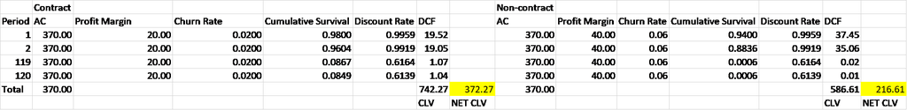

Figure 1. Verification Result: Using Excel to Calculate Aggregated CLV

### Discussion & Recommendations

Our simulation model can help Virgin Mobile decide if it should provide a contract plan or non-contractual pay-per-use scheme to customers, in order to maximize average customer life value and total profit. Virgin Mobile can use this information to set customer acquisition cost limits and marketing budget or target. In reality, Virgin Mobile can use its historical data to better estimate variables used in the model, such as churn rate and customer actual usage. Other relevant decisions, such as contract period, monthly contract fee and pay-per-use pricing schemes can be supplied to the model to evaluate the optimal pricing scheme.

A future extension for this model is to consider the scenario of multiple contract plans with different pricings, which is what telecommunication companies usually provide. Other inputs including customers’ likelihood of choosing different plans (which is often linked to their talk time usage), different plans’ usage limit and prices need to be included in the model. We can incorporate linear regression or bootstrapping to simulate when model inputs are correlated. Customer segmentation analysis can be incorporated to more accurately estimate CLV for the heterogeneous customer base.

While our model can shed light on decision making under uncertain churn rates, acquisition cost and customer usage, there are other uncertainties that this model cannot account for. One such example is churning of customers affected by random events such as competitors’ offers or customer health issues. In reality, a customer’s behavior and lifetime value is not static. Such dynamics are difficult to capture with Monte Carlo simulation, making the model less useful in the long term.